# Introducere

**Serviciul Tematic Seismologie (STS)** din cadrul platformei **SETTING** pune la dispoziția utilizatorilor o gamă variată de informații relevante atât pentru domeniul particular al Seismologiei, cât și pentru cel general al Științelor Pământului.

**Date brute** - sunt reprezentate de înregistrările seismice (seriile de timp sau forme de undă) obținute la stațiile seismice. Institutul Național de Cercetare Dezvoltare pentru Fizica Pământului și-a dezvoltat infrastructura Rețelei Seismice Naționale (RSN) bazându-se pe standardele internaționale definite și adoptate de organizația globală FDSN (Federația Internațională a Rețelelor Seismice Digitale - www.fdsn.org).

**Produse seismologice** - se pot împărți în două categorii:

- produse derivate în urma unor procesări sau analize făcute direct pe formele de undă
- produse rezultate în urma unor studii, analize bazate pe mai multe tipuri de date.

**Servicii** - estimarea rapidă și reprezentarea severității mișcării terenului generată de un cutremur important (**ShakeMap**), estimarea rapidă a pagubelor generate de un cutremur în România, sub formă de clădiri afectate și pierderi socio-economice (**SEISDARO**)

Pe baza **inventarului** **datelor, produselor și serviciilor (DPS)** existente la nivel național relevante pentru STS, au fost identificate următoarele DP integrabile în STS:

- **Lista stații seismice**
- **Date brute – Forme de undă brute**
- **Produse derivate – Forme de undă procesate**
- **Produse hazard și risc seismic**
- **Catalog de cutremure**
- **Zone seismogene**
- **Catalog de mecanisme**
- **Parametrii mișcării terenului**
- **Spectre de răspuns și Fourier**
- **Nivel zgomot stații**
- **Informații despre disponibilitate date**
- **Răspuns local stații**
- **Modele locale de Viteză**
- **Catalog viteze unde S București**
- **Catalog falii**
- **Date Macroseismice**
- **Distribuții parametri mișcare teren**

# ArcGIS Notebook

Oferă o platformă construită pe Jupyter Notebook și optimizată pentru crearea și partajarea de dcoumente care conțin cod Python. Cu ArcGIS Notebook se pot efectua analize spațiale și vizualiza rapid rezultatele într-un context geografic, se pot documenta, automatiza și salva fluxuri de lucru, se pot utiliza resurse Python ale Esri - ArcGIS API for Python și ArcPy - precum și alte biblioteci Pyrhton populare de analiză, statistică și/sau învățare automată open source.

# Noțiuni de bază Jupyter Notebook

### Aceasta e o celulă.

O celulă poate fi de tip:

- code (permite scrierea unui cod Python)
- markdown (permite scrierea unui text formatat)

O celulă se rulează cu SHIFT-ENTER sau apăsând Run din bara de instrumente. Celulele care conțin cod pot fi executate în orice ordine se doreste, ori de câte ori se doreste, iar rezultatele codului executat apar imediat după celula in care e scris codul.

```python
# acesta este un comentariu

print('Această celula conține cod python, iar rezultatul e afișat în celula output')   # acesta este un comentariu
# acesta este un comentariu
```

```
Această celula conține cod python, iar rezultatul e afișat în celula output
```

# Module Python de bază necesare rulării notebook-ului

## Pandas

Este una dintre cele mai importante librării pentru analiza datelor din Python:

- ușor de folosit
- integrată cu alte instrumente folosite în analiza datelor
- ajută la pregătirea datelor pentru domenii precum machine learning

Mai multe despre Pandas găsiți **[aici](https://www.learndatasci.com/tutorials/python-pandas-tutorial-complete-introduction-for-beginners/)**

## Matplotlib

Este una dintre cele mai importante și populare librării pentru vizualizarea datelor din Python. Ce face această librărie? Ajută la transformarea datelor în reprezentări grafice mult mai ușor de urmărit și înteles:

- oferă control asupra oricărui aspect al unei figuri
- permite realizarea unor figuri simple sau complexe atât 2D cât și 3D
- oferă o multitudine de formate pentru figurile create (jpeg, png, svg, etc.)
- integrat direct cu Pandas

Mai multe despre Matplotlib găsiți **[aici](https://matplotlib.org/3.3.1/tutorials/index.html)**

## NumPy: Analiza numerica a datelor in Python

O librarie fundamentala pentru calcule stiintifice in Python. Un tool pentru crearea si manipularea eficienta a datelor numerice:

- introduce suport pentru calcul numeric si matrici multi-dimensionale
- integreaza o gama mare de functii matematice (algebra lineara, transformata Fourier)
- un instrument principal pentru calcule numerice tip High-Performance Computing (HPC)
- constituie baza pentru aplicatii machine learning si IA
- ofera performanta codurilor bine-optimizate in C (in spatele NumPy)
- usor de folosit
- open source

Mai multe despre Numpy găsiți **[aici](https://numpy.org/doc/stable/user/absolute_beginners.html)**

## ObsPy - un mediu Python pentru seismologie

Este un o colecție de programe **open-source** dezvoltate în vederea furnizării unui cadru de lucru în Python pentru **achiziția/prelucrarea și analiza** datelor seismologice (**[Beyreuther et al. 2010](http://www.seismosoc.org/Publications/SRL/SRL_81/srl_81-3_es/)**, **[Megies et al. 2011](https://www.annalsofgeophysics.eu/index.php/annals/article/view/4838)**, **Krischer et al. 2015**).  
Principalele tipuri de date cu care lucrăm în seismologie sunt:

- **înregistrări** provenite de la stațiile seismice (***forme de undă***)
- date despre stațiile seismice (de exemplu ***coordonatele stației, tipul de senzori, etc.***)
- **cataloage de cutremure** - reprezintă o grupare de informații tehnice despre cutremurele produse în anumite zone ale lumii (de exemplu ***timpul la origine, coordonatele cutremurului, adâncimea, magnitudinea, intensitatea, etc.***)

**ObsPy** oferă instrumentele necesare utilizării acestor tipuri de date în cercetările seismologice (procesare de bază a semnalelor, afișarea formelor de undă, rotirea traselor seismice, analiza în domeniul spectral, analiza cataloagelor seismice, etc.) (**[Tutorial ObsPy pagina oficială](https://docs.obspy.org/tutorial/index.html)**).

### Instalare bibliotecă **ObsPy** pentru **ArcGIS Online**

```python
pip install obspy==1.4.0
```

```
     |████████████████████████████████| 14.5 MB 13.1 MB/s eta 0:00:01
```

### Instalare bibliotecă **ObsPy** pentru **ArcGIS Pro**

1. **'Clonarea'** mediului Python creat în mod implicit la instalarea ArcGIS Pro
- se deschide ArcGIS Pro
- se alege ***Settings*** -> ***Package Manager***
  - La **Active Environment** trebuie să fi selectat ***arcgispro-py3*** (mediul Python implicit)
  - Se apasă rotița din dreapta ***arcgispro-py3*** și se deschide fereastra **Environment Manager**
  - Se apasă cele 3 puncte din dreptul ***arcgispro-py3*** și se selectează ***Clone***
  - Se deschide fereastra **Clone Environment** în care se trece:
    - la ***Source*** - ***C:\Program Files\ArcGIS\Pro\bin\Python\envs\arcgispro-py3***
    - la ***Destination*** - ***C:\Users\bogdangrecu\AppData\Local\ESRI\conda\envs\arcgispro-py3-clone***
    - se apasă ***Ok*** și se așteaptă clonarea mediului Python implicit
    - se selectează la **Active Environment** ***arcgispro-py3-clone*** ca mediu de lucru Python
  - Se apasă ***Ok*** și se inchide ArcGIS Pro
2. Se deschide aplicația **Python Command Prompt**
3. Directorul de lucru în care se deschide fereastra trebuie să fie ***C:\Users\bogdangrecu\AppData\Local\ESRI\conda\envs\arcgispro-py3-clone>***. Acesta ne spune că mediul de lucru Python este* *arcgispro-py3-clone**
4. Se instalează bilbioteca **ObsPy** folosind comanda: ***pip install obspy==1.3.1***
5. Se închide fereastra **Python Command Prompt**
6. Se deschide ArcGIS Pro și se verifică dacă s-a instalat biblioteca **ObsPy**: se inițiază un proiect nou apăsând **Start without a template** și din bara de meniuri se alege ***New Notebook***; în prima celulă a notebook-ului se scrie și rulează comanda* **import obspy***. Lipsa unui mesaj de eraore/avertizare se traduce prin instalare cu succes a bibliotecii* *ObsPy**!!!

## arcgis.gis

Pentru conectarea la funcțiile, instrumentele și serviciile GIS

```python
from arcgis.gis import GIS
gis = GIS("home")
```

# Descărcare, procesare, vizualizare DP Seismologie

## Descărcare catalog ROMPLUS

```python
# requests - modul Python pentru transmiterea de cereri HTTP
import requests

# creare set date din catalogul ROMPLUS aflat pe site-ul INFP
response = requests.get('http://www.infp.ro/data/romplus.txt')
romplus = response.text
romplus = romplus.replace('f', '')
romplus = romplus[0:].split('\n')[:-2]

# creare lista header
header = 'Date,Time,Latitude,Longitude,Depth,Ml,Mw\n'

# scriere catalog Romplus in format csv (doar cu 7 coloane)
with open("romplus.csv", 'w') as f:
    f.write(header)
    for i in range(2, len(romplus)):   ### i=2 catalogul incepe cu anul 1022
        linie_romplus = romplus[i]
        data = linie_romplus[0:11].split()[0]
        ora = linie_romplus[12:24].split()[0]
        lat = linie_romplus[37:45].split()[0]
        lon = linie_romplus[48:56].split()[0]
        depth = linie_romplus[75:81].split()[0]
        ml = linie_romplus[87:91].split()[0]
        mw = linie_romplus[107:111].split()[0]
        linie = ",".join([data, ora, lat, lon, depth, ml, mw + '\n'])
        f.write(linie)
```

## Utilizare bibliotecă Pandas pentru analiza și selectarea evenimentelor din catalogul Romplus

```python
import pandas as pd
from obspy import UTCDateTime

data_inceput = '2018-01-01'

#creare dataframe cu Romplus-ul

df = pd.read_csv('romplus.csv', index_col='Date', parse_dates=True)

# selectie cutremure intermediare cu Ml > 3 începând cu 1 ianuarie 2018
df = df[(df['Depth'] >= 60.0) & (df['Ml'] >= 3.0) & (df.index >= UTCDateTime(data_inceput))]

df.to_csv('romplus.csv', sep=',')
df.head(10)
```

| Date | Time | Latitude | Longitude | Depth | Ml | Mw |
| --- | --- | --- | --- | --- | --- | --- |
| 2018/01/19 | 14:58:10.08 | 45.7915 | 26.7873 | 103.4 | 3.0 | 3.0 |
| 2018/01/26 | 06:21:15.61 | 45.5709 | 26.4766 | 114.4 | 3.1 | 3.1 |
| 2018/01/26 | 07:42:29.93 | 45.5667 | 26.5111 | 127.1 | 3.3 | 3.2 |
| 2018/01/27 | 06:48:12.12 | 45.6316 | 26.4595 | 91.2 | 3.5 | 3.0 |
| 2018/01/28 | 21:22:09.91 | 45.5143 | 26.5246 | 104.3 | 3.3 | 3.2 |
| 2018/02/03 | 01:00:26.45 | 45.5005 | 26.4062 | 125.7 | 3.6 | 3.5 |
| 2018/02/04 | 13:15:05.10 | 45.5398 | 26.3800 | 140.8 | 3.9 | 3.7 |
| 2018/02/04 | 23:56:39.73 | 45.7346 | 26.6298 | 82.8 | 3.3 | 3.2 |
| 2018/02/09 | 20:22:57.27 | 45.5555 | 26.4611 | 120.4 | 3.0 | 3.0 |
| 2018/02/10 | 22:32:17.98 | 45.5989 | 26.5206 | 127.6 | 3.2 | 3.2 |

|  | Ml | Depth |
| --- | --- | --- |
| count | 503.000000 | 503.000000 |
| mean | 3.407356 | 117.108549 |
| std | 0.398410 | 23.216939 |
| min | 3.000000 | 62.400000 |
| 25% | 3.100000 | 104.050000 |
| 50% | 3.300000 | 122.200000 |
| 75% | 3.600000 | 134.550000 |
| max | 5.800000 | 196.000000 |

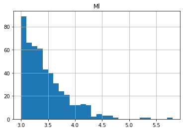

```python
# histograme și diverse statistici folosind Pandas
df.hist(column='Ml', bins=28)

df[['Ml', 'Depth']].describe()
```

## Utilizare bibliotecă Matplotlib pentru realizare de grafice bazate pe datele din Romplus

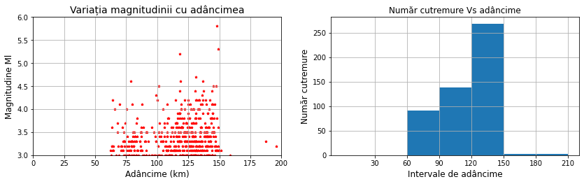

```python
# afisare variatia magnitudinii Ml cu adâncimea
import matplotlib.pyplot as plt
%matplotlib inline

fig = plt.figure(figsize=(14, 8))
axe1 = fig.add_subplot(221)
axe1.scatter(df['Depth'], df['Ml'],
            color='red', marker='*', s=10 )
axe1.set_xlabel('Adâncime (km)', fontsize=12)
axe1.set_ylabel('Magnitudine Ml', fontsize=12)
plt.xlim(0, 200)
plt.ylim(3, 6)
plt.grid()
plt.title('Variația magnitudinii cu adâncimea', fontsize=14)

# histograma cutremurelor in functie de adâncime
axe2 = fig.add_subplot(222)
axe2.hist(df['Depth'], bins=[0, 30, 60, 90, 120, 150, 180, 210])
axe2.set_xticks([30, 60, 90, 120, 150, 180, 210])
axe2.set_xlabel('Intervale de adâncime', fontsize=12)
axe2.set_ylabel('Număr cutremure', fontsize=12)
plt.grid()
plt.title('Număr cutremure Vs adâncime', fontsize=12)
plt.show()
```

## Reprezentare pe hartă a epicentrelor folosind librăria arcgis.gis

```python
# adauga fisierul csv in My Content
# csv_file = '/arcgis/romplus.csv'
# csv_item = gis.content.add({}, csv_file)

# display(csv_item.id)
```

```python
# Adaugare epicentre cutremure pe harta dupa ce in prealabil a fost creat fisierul romplus de tip Feature layer

vr_map = gis.map('Vrancea', zoomlevel=8)

romplus_item = gis.content.get('72a3c662fb444c76909f875fb7b5bdda')

vr_map.add_layer(romplus_item)

vr_map
```

```
MapView(layout=Layout(height='400px', width='100%'))
```

[figure not shown]

## Descărcare și vizualizare forme de undă folosind ObsPy

Pentru a identifica un canal de date de la o stație seismică se folosesc următoarelor informații:

- **Cod Rețea** - identificarea rețelei care furnizează datele
- **Cod Stație** - identificarea stației seismice
- **ID Locație** - identificarea diferitelor ***stream-uri*** de date de la o stație
- **Cod Canal** - identificarea tipului de canal (bandă larga, perioadă scurtă)

Exemplu: RO.MLR..HHZ

Cele întâlnite și folosite formate de date pentru înregistrările seismice sunt:

- **miniseed** - ceea ce se obține de la centrele de date internaționale; conține puțini parametrii (de exemplu codul stației, canalul, rata de ețantionare, etc.); un fișier poate avea mai multe componente; permite situații în care avem suprapuneri de date (overlaps) sau lipsă de date (gaps).
- **sac** - a fost conceput pentru programul de analiză SAC (Seismic Analysis Code); conține un header în care pot fi trecute atât înformații despre stație (latitudine, longitudine, elevație, etc.) cât și despre eveniment (timpul la origine, coordonate epicentru, adâncime, magnitudine, etc.); acceptă un singur canal per fișier.

Alte formate: AH, CSS, GCF, GSE, Q, Pickle, ASCII, WAV, SEGY, SEG2, etc.

ObsPy permite descărcarea datelor seismologice folosind diferite tipuri de servicii:

- **servicii web FDSN**
- **servicii ArcLink**
- **servicii Earthworm**
- **servicii IRIS**
- **servicii NEIC**
- **servicii NERIES**

Mai jos arătăm cum funcționează un client ObsPy pentru accesarea unui serviciu web FDSN; cele mai multe centre internaționale au implementat acest serviciu; clienții pentru alte servicii funcționează precum cel pentru FDSN. Un obiect client FDSN poate fi inițializat fie cu adresa URL de bază a oricărui serviciu web FDSN, fie cu numele furnizorului FDSN. Furnizorii de date disponibili în prezent pot fi identificați folosind comenzile:

```python
from obspy.clients.fdsn.header import URL_MAPPINGS

for key in sorted(URL_MAPPINGS.keys()):
    print("{0:<11} {1}".format(key,  URL_MAPPINGS[key]))
```

```
AUSPASS     http://auspass.edu.au
BGR         http://eida.bgr.de
EIDA        http://eida-federator.ethz.ch
EMSC        http://www.seismicportal.eu
ETH         http://eida.ethz.ch
GEOFON      http://geofon.gfz-potsdam.de
GEONET      http://service.geonet.org.nz
GFZ         http://geofon.gfz-potsdam.de
ICGC        http://ws.icgc.cat
IESDMC      http://batsws.earth.sinica.edu.tw
INGV        http://webservices.ingv.it
IPGP        http://ws.ipgp.fr
IRIS        http://service.iris.edu
IRISPH5     http://service.iris.edu
ISC         http://isc-mirror.iris.washington.edu
KNMI        http://rdsa.knmi.nl
KOERI       http://eida.koeri.boun.edu.tr
LMU         http://erde.geophysik.uni-muenchen.de
NCEDC       http://service.ncedc.org
NIEP        http://eida-sc3.infp.ro
NOA         http://eida.gein.noa.gr
ODC         http://www.orfeus-eu.org
ORFEUS      http://www.orfeus-eu.org
RASPISHAKE  https://fdsnws.raspberryshakedata.com
RESIF       http://ws.resif.fr
RESIFPH5    http://ph5ws.resif.fr
SCEDC       http://service.scedc.caltech.edu
TEXNET      http://rtserve.beg.utexas.edu
UIB-NORSAR  http://eida.geo.uib.no
USGS        http://earthquake.usgs.gov
USP         http://sismo.iag.usp.br
```

```python
# selectie cutremure intermediare cu Ml > 5 începând cu 1 ianuarie 2018
df = df[(df['Ml'] >= 5.0) & (df.index >= UTCDateTime(data_inceput))]
df
```

| Date | Time | Latitude | Longitude | Depth | Ml | Mw |
| --- | --- | --- | --- | --- | --- | --- |
| 2018/10/28 | 00:38:11.39 | 45.6079 | 26.4068 | 147.8 | 5.8 | 5.5 |
| 2020/01/31 | 01:26:47.91 | 45.6937 | 26.6918 | 118.2 | 5.2 | 4.8 |
| 2022/11/03 | 04:50:25.81 | 45.4895 | 26.5262 | 149.0 | 5.3 | 4.9 |

```
FDSN Webservice Client (base url: http://eida-sc3.infp.ro)
Available Services: 'dataselect' (v1.1.0), 'event' (v1.2.2), 'station' (v1.1.2), 'available_event_catalogs', 'available_event_contributors', 'eida-auth'

Use e.g. client.help('dataselect') for the
parameter description of the individual services
or client.help() for parameter description of
all webservices.
```

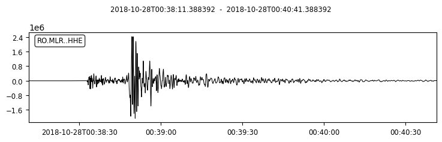

```
1 Trace(s) in Stream:
RO.MLR..HHE | 2018-10-28T00:38:11.388392Z - 2018-10-28T00:40:41.388392Z | 100.0 Hz, 15001 samples
```

```python
# afișare forme de unda înregsitrată la stația MLR in timpul celui mai puternic cutremur din 2018 până în prezent

from obspy import UTCDateTime   # necesar pentru a lucra cu obiecte de tip data, timp
from obspy.clients.fdsn import Client

data_provider = "NIEP"
client = Client(data_provider)
print(client)

timp_origine = UTCDateTime("2018-10-28T00:38:11.39")

[start, end] = [ 0, 150 ]   # pentru lungimea ferestrei taiate

st = client.get_waveforms('RO', 'MLR', '--', 'HHE', timp_origine - start, timp_origine + end, attach_response = False)

st.plot(linewidth=0.75)
print(st)
```

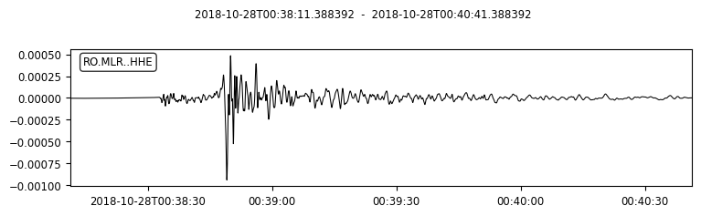

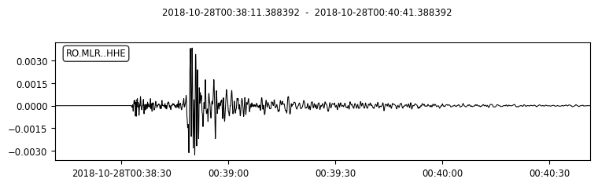

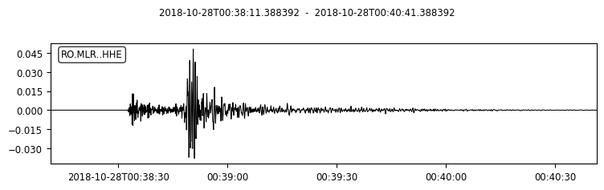

```python
# afișare formă de undă în unități fizice (m, m/s, m/s*s)
st1 = client.get_waveforms('RO', 'MLR', '--', 'HHE', timp_origine - start, timp_origine + end, attach_response = True)
st2 = client.get_waveforms('RO', 'MLR', '--', 'HHE', timp_origine - start, timp_origine + end, attach_response = True)
st3 = client.get_waveforms('RO', 'MLR', '--', 'HHE', timp_origine - start, timp_origine + end, attach_response = True)
st1.remove_response(output="DISP")
st2.remove_response(output="VEL")
st3.remove_response(output="ACC")
st1.plot(linewidth=0.75)
st2.plot(linewidth=0.75)
st3.plot(linewidth=0.75)
print()
```

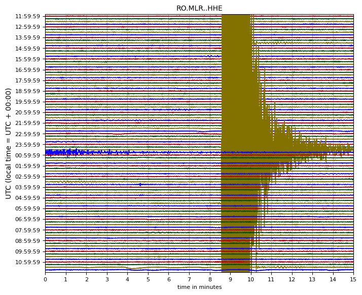

```
RO.MLR..HHE | 2018-10-27T11:59:59.998392Z - 2018-10-28T11:59:59.998392Z | 100.0 Hz, 8640001 samples
```

```python
# afisare inregistrare o zi sub forma unui helicorder


timp = UTCDateTime("2018-10-27T12:00:00.00")

[start, end] = [ 0, 86400 ]   # pentru lungimea ferestrei taiate

st = client.get_waveforms('RO', 'MLR', '--', 'HHE', timp - start, timp + end, attach_response = False)

st.plot(type='dayplot')

print(st[0])
```

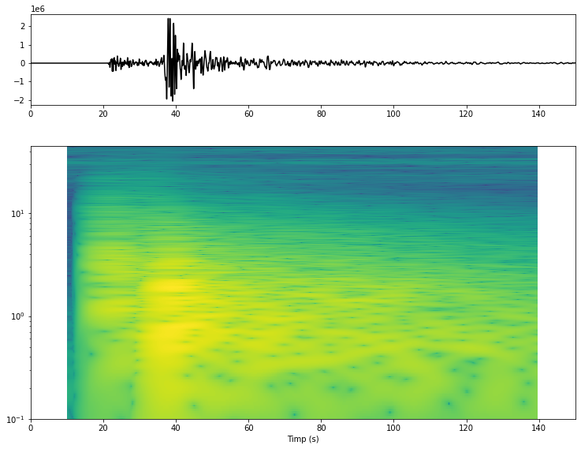

```python
# afișarea spectrogramei

import numpy as np

timp_origine = UTCDateTime("2018-10-28T00:38:11.39")

[start, end] = [ 0, 150 ]   # pentru lungimea ferestrei taiate

st = client.get_waveforms('RO', 'MLR', '--', 'HHE', timp_origine - start, timp_origine + end, attach_response = False)

sps = int(st[0].stats.sampling_rate)

# st.plot()

fig = plt.figure(figsize=(12,8))
ax1 = fig.add_axes([0.1, 0.79, 0.8, 0.2])
ax2 = fig.add_axes([0.1, 0.1, 0.8, 0.60], sharex=ax1)

trasa = st[0]
vector_timp = np.arange(trasa.stats.npts) / trasa.stats.sampling_rate
ax1.plot(vector_timp, trasa.copy().data, 'k')

trasa.spectrogram(wlen=2*sps, per_lap=0.99,
    dbscale=True, log=True, axes=ax2)
ax2.set_ylim((0.1,45))
ax2.set_xlabel('Timp (s)')
```